# Explore_Loan_Data

Brahmi Ibtissam

9 septembre 2018

```
## [1] "C:/Users/hp/Desktop/udacity_nanodegree/term2/EDA_with_R/project/Explore-loan-data"
```

> We can see the variables descriptions of the data at the link https://docs.google.com/spreadsheets/d/1gDyi_L4UvIrLTEC6Wri5nbaMmkGmLQBk-Yx3z0XDEtI/edit#gid=0

> To help ourselves understand the variables and the relationship between them and answer relevant questions, and since we have 81 variables, we’ll select the key ones by subseting our dataset. We’ll choose  
> LoanOriginalAmount BorrowerRate LoanStatus IncomeRange BorrowerState ListingCategory EmploymentStatus Occupation CurrentCreditLines ListingKey LoanKey OnTimeProsperPayments.

# Univariate Analysis

## First to get realy started with our data and get deep understanding of it, we’ll produce summaries and visualizations of each individual variable

```
## [1] 113937     81
```

> Our Dataset consists of 81 variables with almost 113937 observations, we reduced the number of variable to 13.

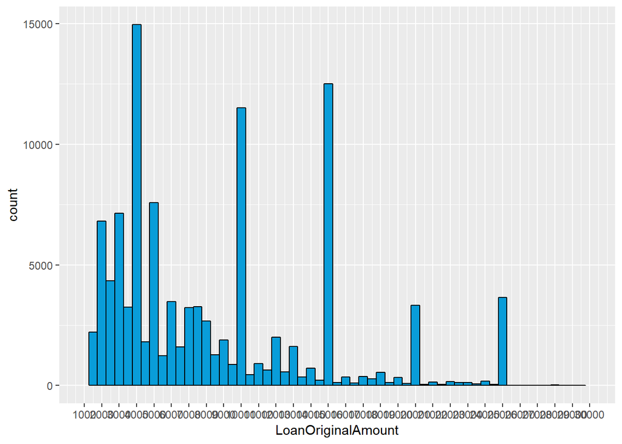

We notice the presence of 3 peaks: about 15000 borrowrs borrow an amount of 4000 dollars, 10000 dollars is borrowed by about 12000 of Prosper customers, and finally the third peak indicates that 12500 of customers have an original amount loan of 15000 dollars, maybe the three peaks are explained by the difference in monthly incomes and needs.

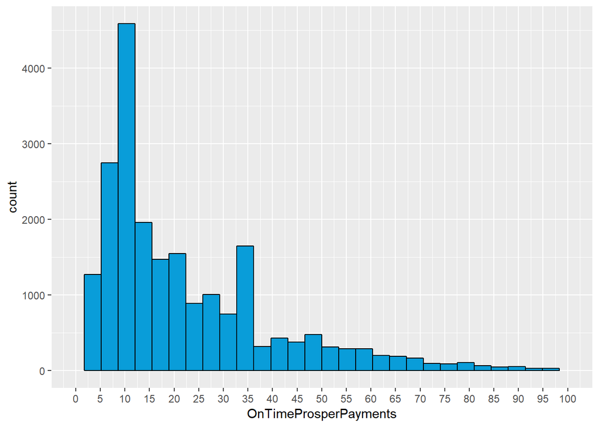

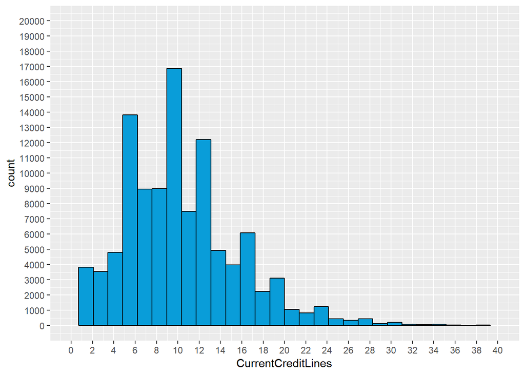

> More than 16000 of borrowers have 10 credit lines at the time the credit profile was pulled.

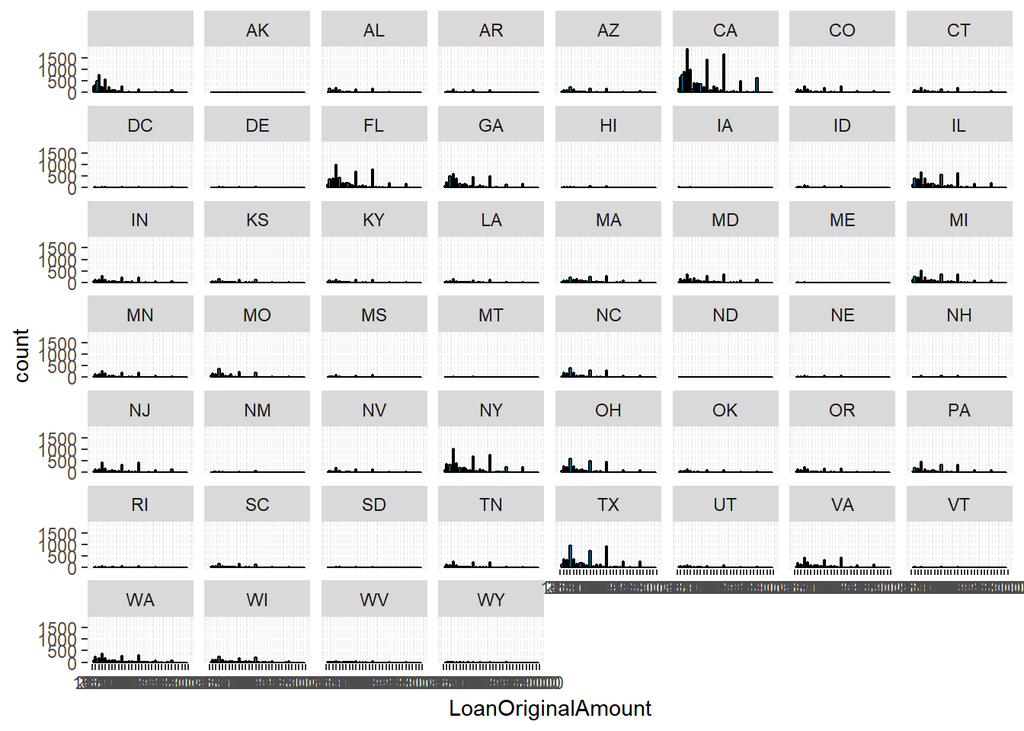

Most of borrowers are from big cities where the standard of living is somewhat expensive: California NewYork Texas Florida…

Factor w/ 21 levels “0”,“1”,“2”,“3”,..: 1 3 1 17 3 2 2 3 8 8 …

We transformed ListingCategory to a factor variablesuch that we can facet with it

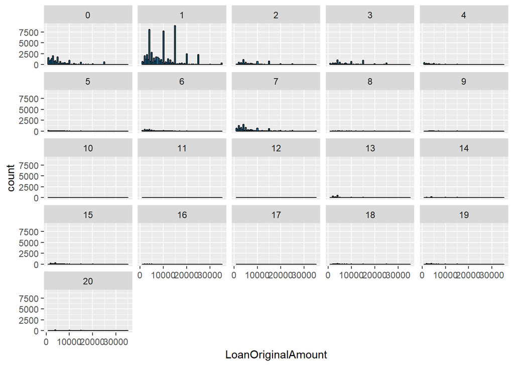

Most of demanded loans are about debt consolidation  
Factor w/ 8 levels “$0”,“$1-24,999”,..: 4 5 7 4 3 3 4 4 4 4 … We arrange our data set by IncomeRange

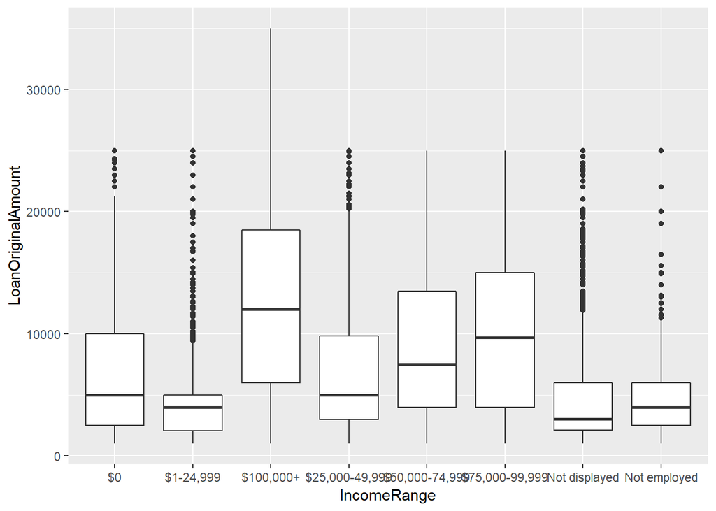

We notice the presence of outliers, especially for 1$-24,900$ class, borrowers with high incomes have the greatest IQR and median.

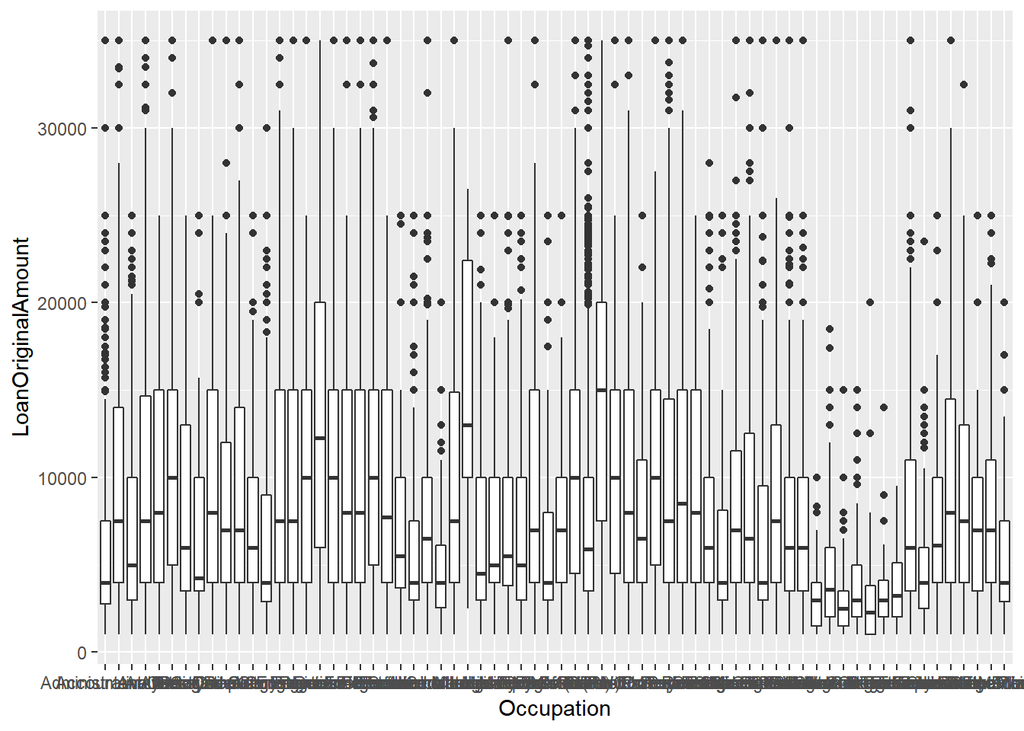

It’s interesting to see whats high loan original amount boorowers occupation, but we have so much levels that we cant’t visualize in a clean manner.

# Bivariate Analysis

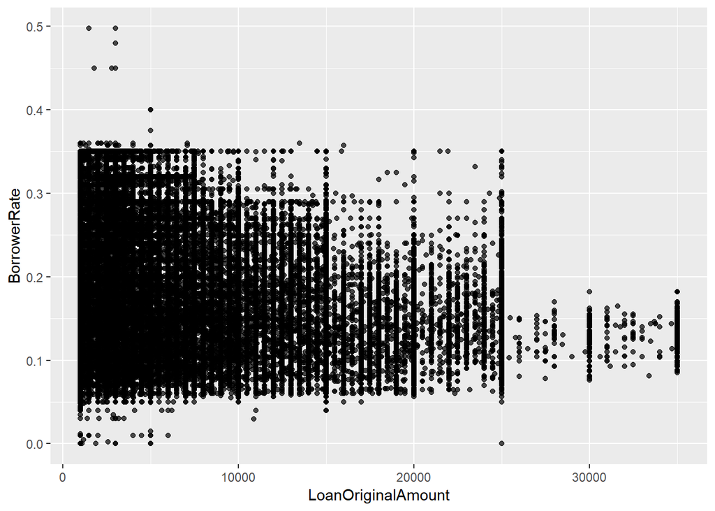

The log scale will be more informative since we have a multiplicative relationship between x and y

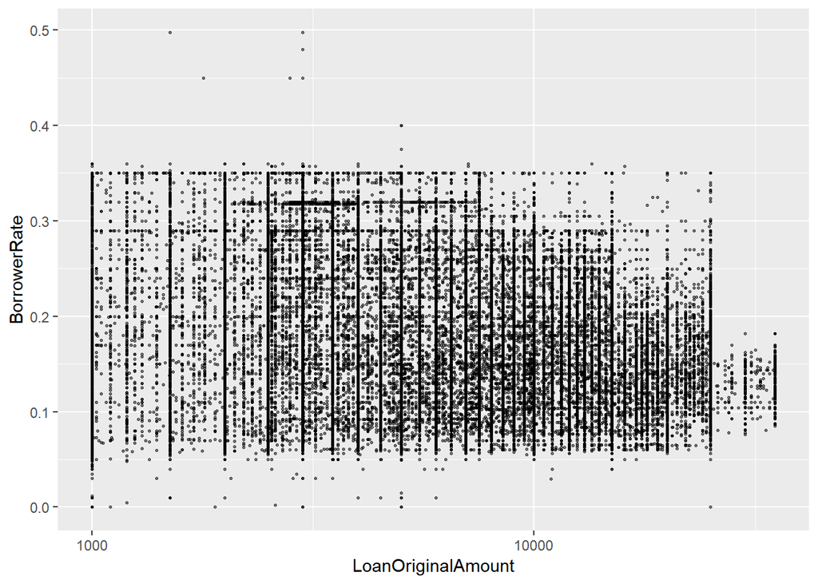

Besides overplotting, we see that for the same loan original amount we have a lot of degrees of borrower rates?!

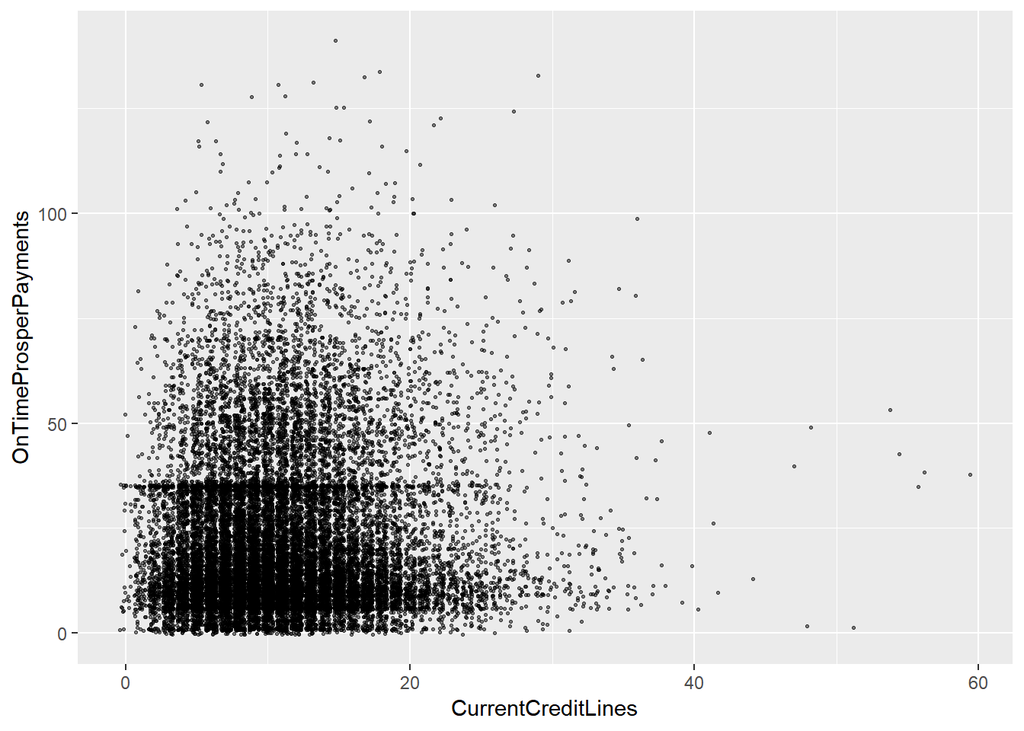

```
Pearson's product-moment correlation
```

data: df_s$CurrentCreditLines and df_s$OnTimeProsperPayments t = 9.5808, df = 22083, p-value < 2.2e-16 alternative hypothesis: true correlation is not equal to 0 95 percent confidence interval: 0.05119330 0.07746164 sample estimates: cor 0.06433861

Expecting that it will be a negative correlation between current credit lines and on time prosper payments, it turns to be 0.06! the distribution seems to be somewhat normal and we also notice the presence of some outliers; for example, someone has about 60 dredit lines at a time, but not even 50 on time payments!

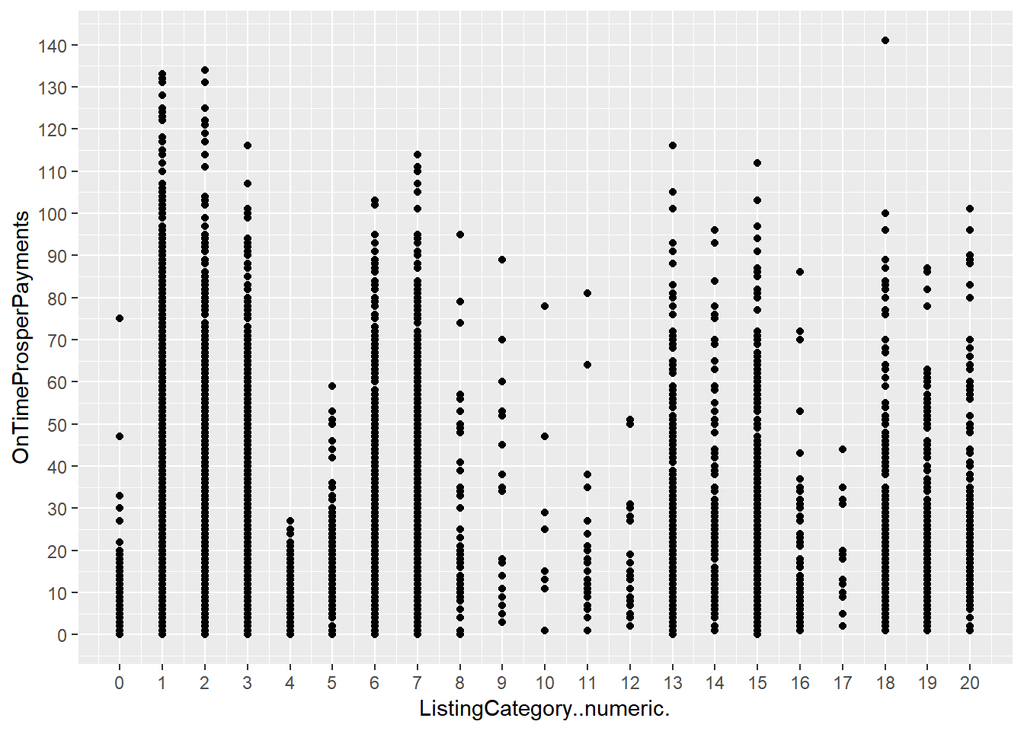

Most of on time prosper payements concern debt consolidation and home improvement, comes in second range Household Expenses and Large Purchases.

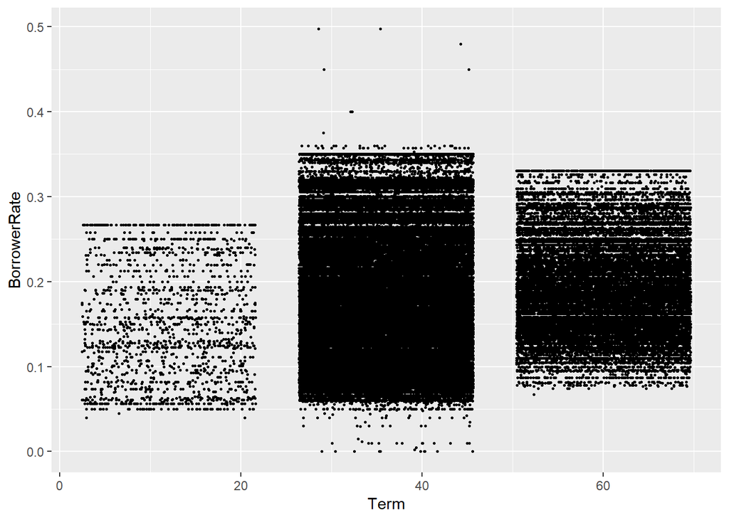

table(df_s$Term) Borrowoers who choose 36 months as a lenght of the loan (middle term) have the highest Borrower Rate

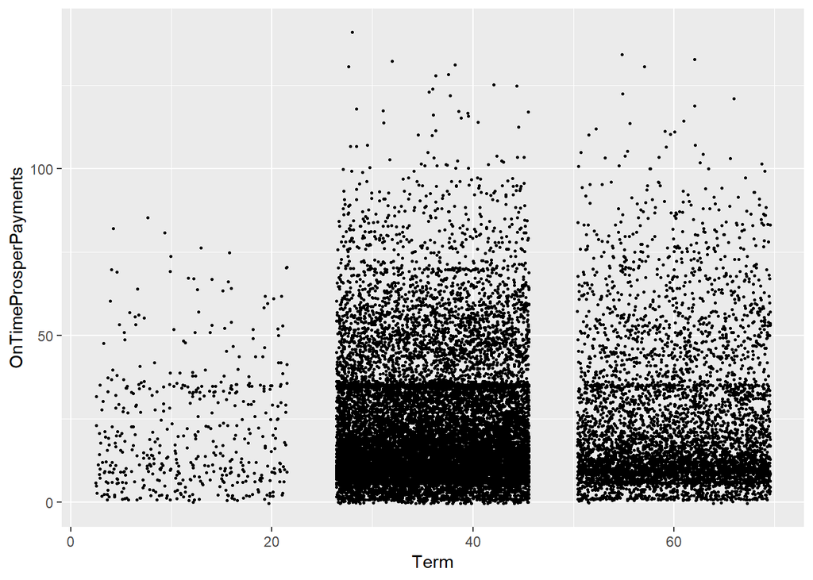

On time Prosper payments is frequent for borrowores who choosed the middle term, maybe we can ask who what is the Income range of those borrowers!

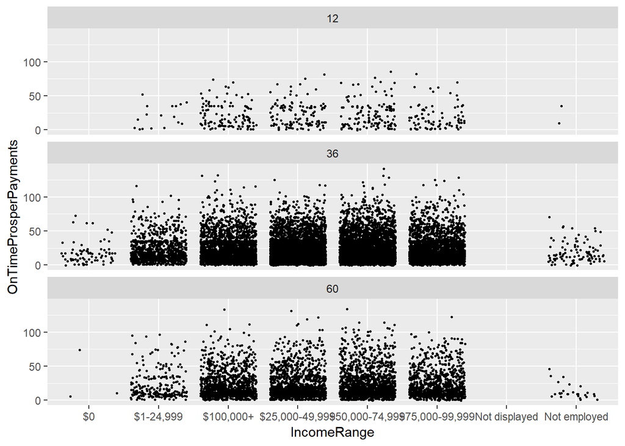

Borrowers with in income range of 25000 and 74999 dollars and divided their loan on 36 months are more prone to pay on time.

Now we’ll be interested to the mean of original amount loan by income range, before, we should order IncomeRange factor variable

table(df_s$Occupation)

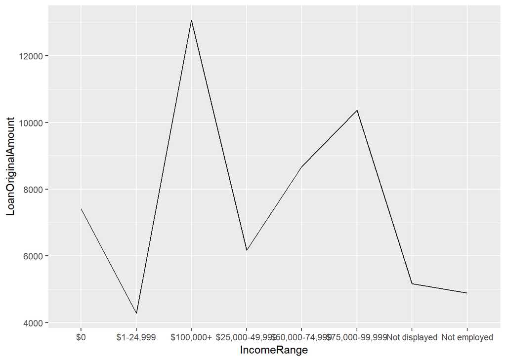

Except the income range between 0$ and 24,999$, as we climb in income ranges the loan original amount increases.

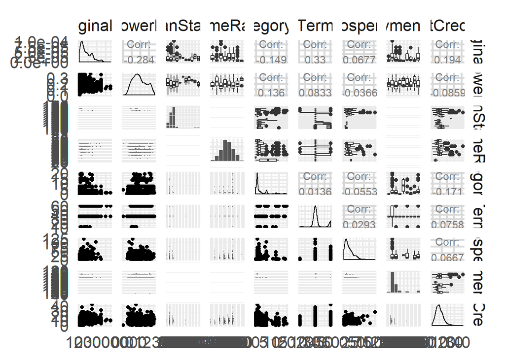

We just discover an interesting relationship between Borrower Rate and Current Credit Line, let’s plot the scatterplot separately

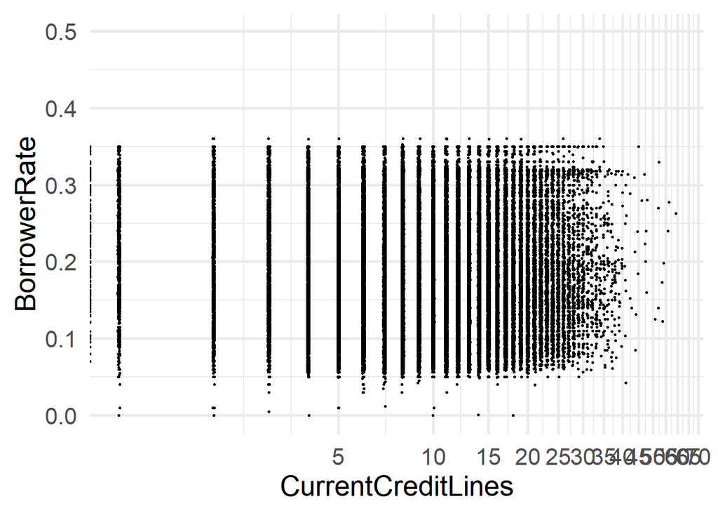

```
Kendall's rank correlation tau
```

data: df_s$BorrowerRate and df_s$CurrentCreditLines z = -36.637, p-value < 2.2e-16 alternative hypothesis: true tau is not equal to 0 sample estimates: tau -0.07717001 ?cor.test

# Multivariate

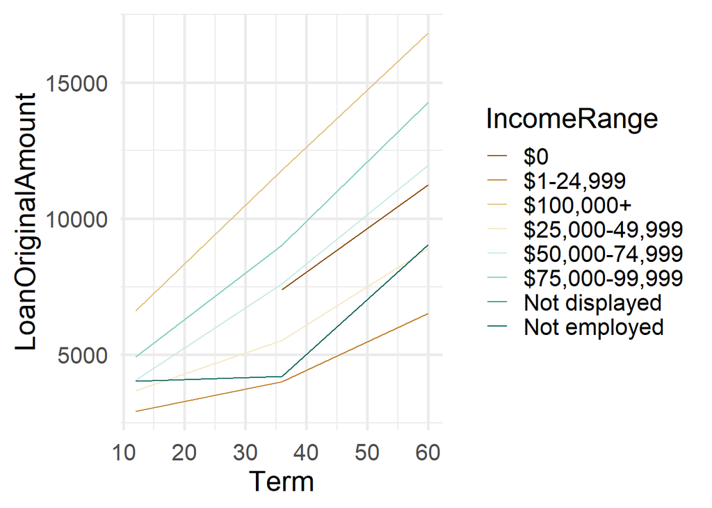

It coud be strange that not employed borrowers loan, in average more than borrowrs that earn more (0-24,999$ income range) Borrowers whose income is more than 100,000 dollars turn to have the greates loan original amount, it seems interesting to discover, why do they borrow this money, in other words, in what Listing category they are interested in. We start by converting ,ListingCategory..numeric. to a categorical variable

df_s$ListingCategory..numeric. <- factor(df_s$ListingCategory..numeric.)

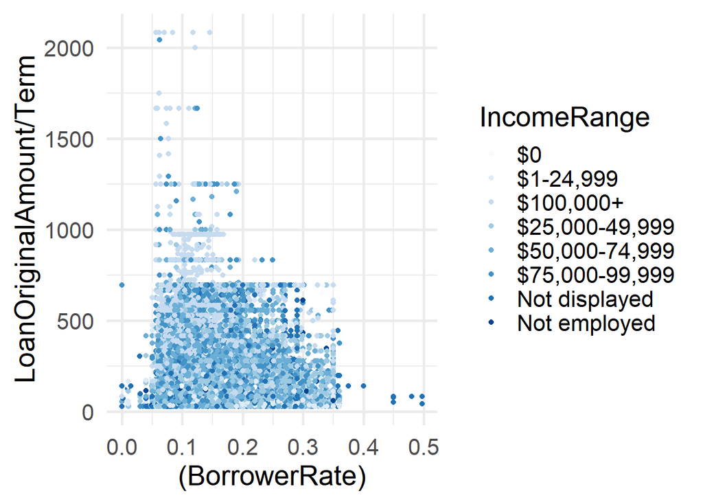

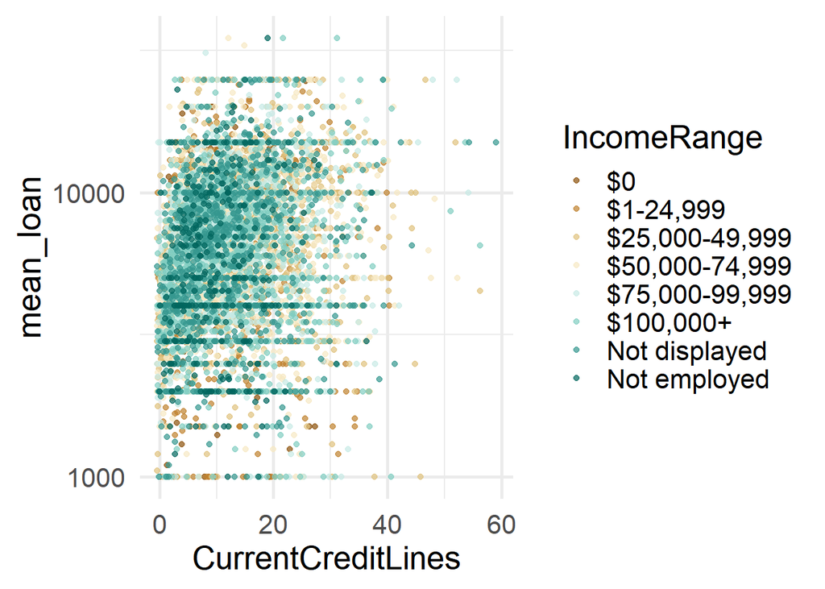

```
Pearson's product-moment correlation
```

data: df_by_income$CurrentCreditLines and df_by_income$mean_loan t = 20.616, df = 8215, p-value < 2.2e-16 alternative hypothesis: true correlation is not equal to 0 95 percent confidence interval: 0.2011367 0.2422551 sample estimates: cor 0.2217945

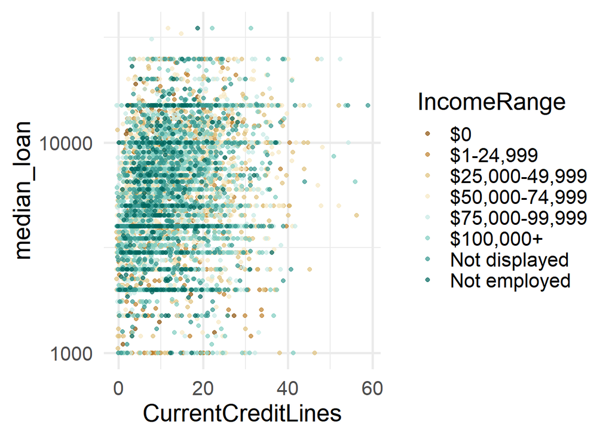

[output not shown]

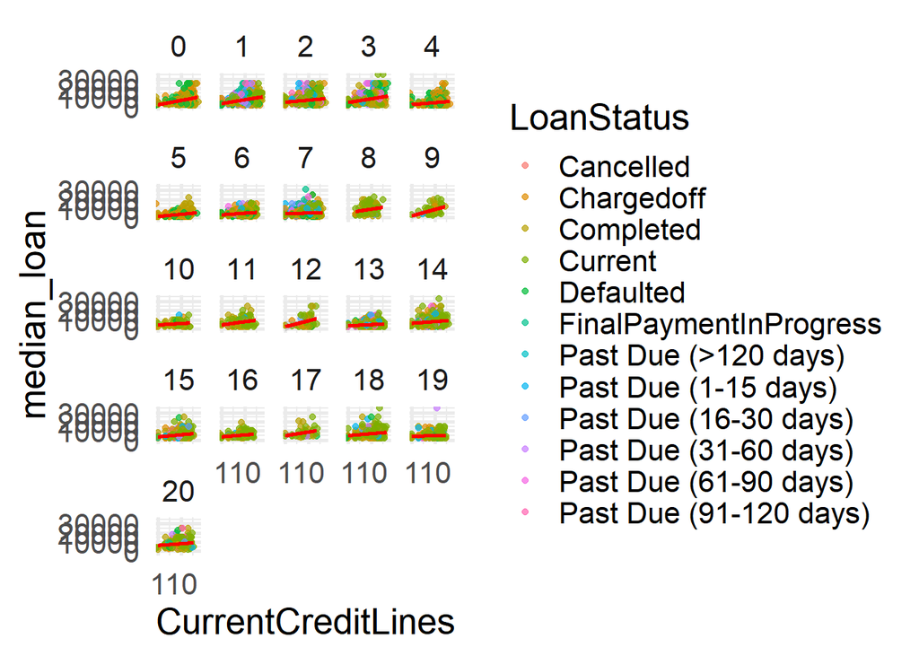

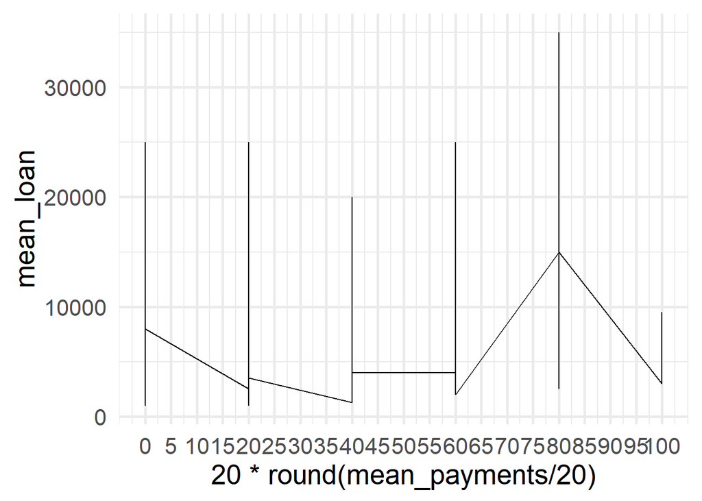

```
Pearson's product-moment correlation
```

data: df_by_income$mean_payments and df_by_income$mean_loan t = 1.3139, df = 990, p-value = 0.1892 alternative hypothesis: true correlation is not equal to 0 95 percent confidence interval: -0.02057483 0.10369465 sample estimates: cor 0.04172126

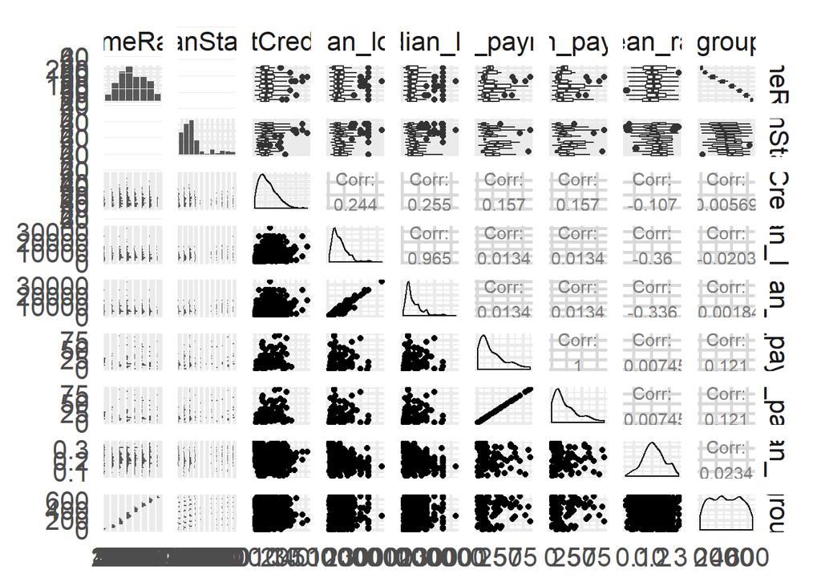

```
Pearson's product-moment correlation
```

data: df_by_income$CurrentCreditLines and df_by_income$mean_rate t = -12.453, df = 8215, p-value < 2.2e-16 alternative hypothesis: true correlation is not equal to 0 95 percent confidence interval: -0.1572737 -0.1148298 sample estimates: cor -0.1361142

```
Pearson's product-moment correlation
```

data: df_by_income$mean_rate and df_by_income$mean_loan t = -34.444, df = 8242, p-value < 2.2e-16 alternative hypothesis: true correlation is not equal to 0 95 percent confidence interval: -0.3734570 -0.3357136 sample estimates: cor -0.3547298

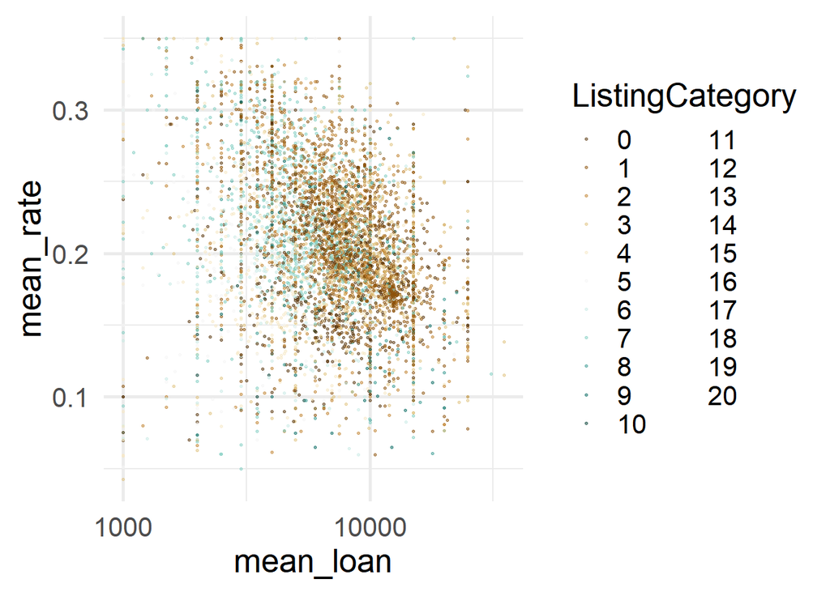